# Concrete Strength Predictive Modeling

Author

Jean Ralph M. PAUL

Abstract

This study investigates the relationship between concrete composition and compressive strength using several regression models. Eight material components serve as predictors to compare three approaches of increasing complexity: Linear Regression, a Generalized Additive Model (GAM), and a Random Forest. The results indicate that while Linear Regression provides a reasonable baseline, it fails to capture the data’s inherent nonlinear patterns. The GAM achieves higher predictive accuracy while remaining interpretable, offering a balanced trade-off between complexity and explainability. Ultimately, the Random Forest model outperforms both alternatives.

## Introduction

Concrete is one of the world’s most widely used construction materials, and its strength is critically important as it directly affects the structural integrity and durability of constructions. The reliable prediction of concrete strength has been the focus of numerous studies, which have proposed various techniques including empirical and computational modeling, statistical methods, and artificial intelligence approaches.

The objective of this project is to implement different statistical models cited in the literature and assess their predictive accuracy.

## Data set description

The dataset used for this study was obtained from: Yeh, I. (1998). Concrete Compressive Strength [Dataset]. UCI Machine Learning Repository. https://archive.ics.uci.edu/dataset/165/concrete+compressive+strength

The table below provides a summary of all attributes. As shown, the dataset contains eight quantitative input features and one quantitative output (concrete compressive strength), with no missing values.

Descriptive Statistics of Concrete dataset

| Variable | Missing Values | Mean | Standard Deviation | Median |
| --- | --- | --- | --- | --- |
| Cement | 0 | 281.165631 | 104.507142 | 272.90000 |
| Blast_Furnace_Slag | 0 | 73.895485 | 86.279104 | 22.00000 |
| Fly_Ash | 0 | 54.187136 | 63.996469 | 0.00000 |
| Water | 0 | 181.566359 | 21.355567 | 185.00000 |
| Superplasticizer | 0 | 6.203112 | 5.973492 | 6.35000 |
| Coarse_Aggregate | 0 | 972.918592 | 77.753818 | 968.00000 |
| Fine_Aggregate | 0 | 773.578883 | 80.175427 | 779.51000 |
| Age | 0 | 45.662136 | 63.169912 | 28.00000 |
| Concrete_strength | 0 | 35.817836 | 16.705679 | 34.44277 |

## Exploratory data analysis

### Outliers detection

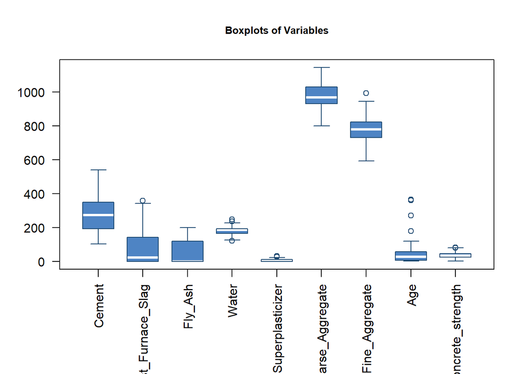

### Pair correlation between attributes

The correlation matrix did not reveal strong pairwise correlations between the variables. However, it is important to note that this result alone does not indicate the absence of multicollinearity.

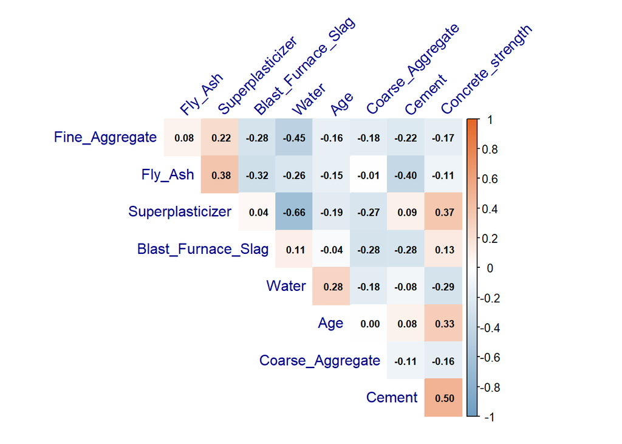

### Relationship between strength and predictors

Scatter plots reveal clear positive relationships between concrete compressive strength and cement content, superplasticizer content, and age. In contrast, water content shows a negative correlation. The other components exhibit more scattered relationships, suggesting weaker individual effects on strength.

These observed relationships justify the use of regression modeling to quantify how material composition affects concrete compressive strength.

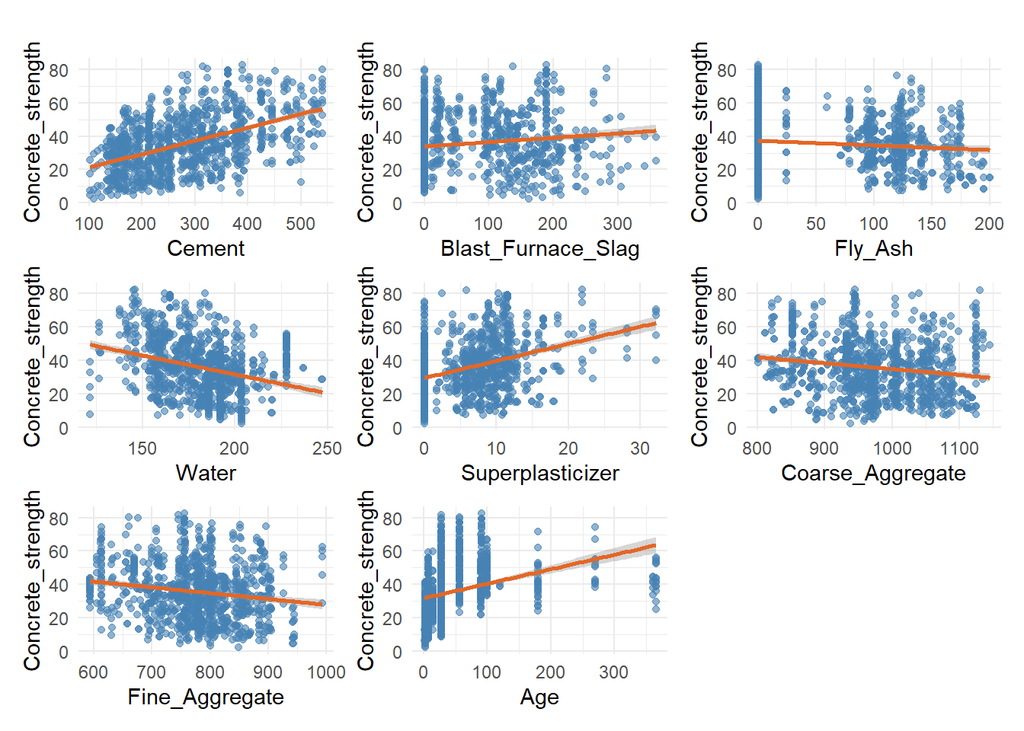

## Modeling

### Model Validation Strategy

Before fitting any predictive models, the dataset was randomly divided into a training set and a validation set to ensure a valid assessment of model performance. A 70/30 split was applied, where the training set was used exclusively for model fitting, feature selection, and hyperparameter tuning. The validation set remained completely untouched until the final evaluation stage.

### Linear regression

Linear regression is one of the most popular and foundational statistical models for predicting concrete compressive strength. Researchers often use multiple linear regression (MLR) to model the relationship between strength and its predictors, frequently accounting for interaction effects.

Our starting point was the full set of candidate variables and key interactions identified in the literature. To improve prediction accuracy and identify the most relevant predictors, we performed best subset selection on this full set. The final model was then fitted using this reduced, optimal subset of variables.

**Best subset selection**

Based on the best subset selection algorithm, the combination of features that yields the lowest test error is as follows:

Optimal Features Selected by Best Subset Selection

[output not shown]

**Results of the Fitted Reduced Model**

| term | estimate | std.error | statistic | p.value |
| --- | --- | --- | --- | --- |
| (Intercept) | 2.659 | 10.178 | 0.261 | 0.794 |
| Cement | 0.115 | 0.005 | 24.430 | 0.000 |
| Blast_Furnace_Slag | 0.089 | 0.006 | 15.727 | 0.000 |
| Fly_Ash | 0.027 | 0.011 | 2.578 | 0.010 |
| Water | -0.090 | 0.030 | -2.973 | 0.003 |
| Superplasticizer | 0.257 | 0.101 | 2.535 | 0.011 |
| Coarse_Aggregate | 0.000 | 0.006 | -0.058 | 0.954 |
| Age | 0.445 | 0.060 | 7.401 | 0.000 |
| Water:Age | -0.002 | 0.000 | -5.853 | 0.000 |
| Fly_Ash:Age | 0.001 | 0.000 | 7.114 | 0.000 |

**Model diagnostic (reduced linear model)**

This section evaluates the model to determine if it satisfies the assumptions of linear regression.

##### Influential observations (cook’s distance analysis)

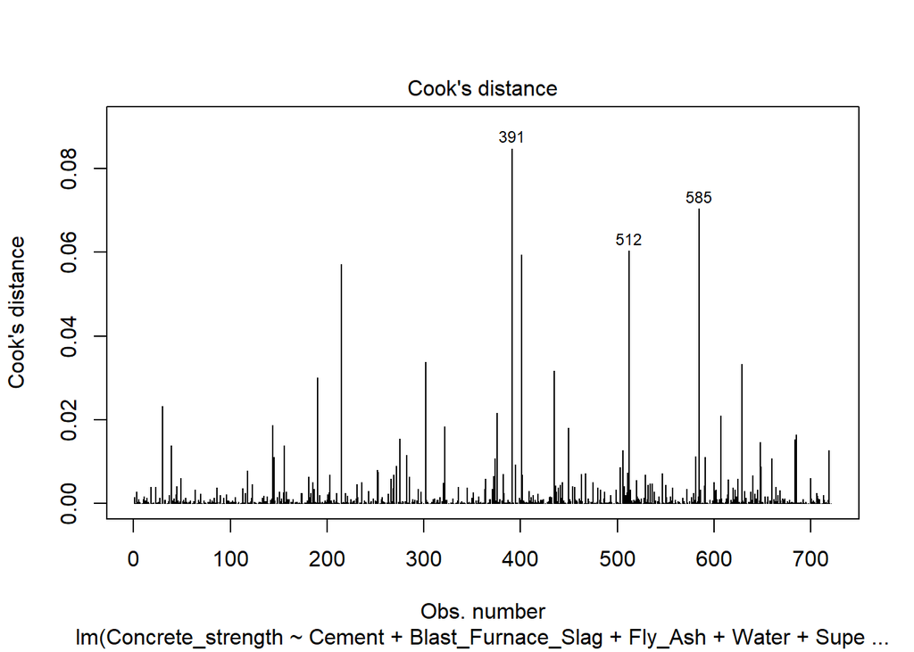

To detect influential observations, Cook’s distance was used as the primary diagnostic measure. All calculated distances were below conventional thresholds, indicating that no individual observation meaningfully affected the fitted model.

##### Q-Q Plot of Residuals (checking Normality Assumption):

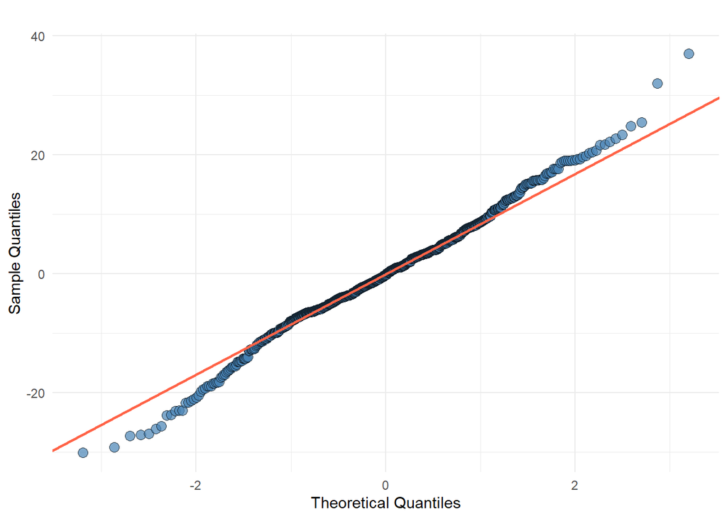

The Q-Q plot shows that the residuals align closely with the theoretical normal distribution, with only minor deviations at the tails. This indicates that the normality assumption is reasonably satisfied.

##### Residuals vs. Fitted Values Plot (checking Linearity and homoscedasticity)

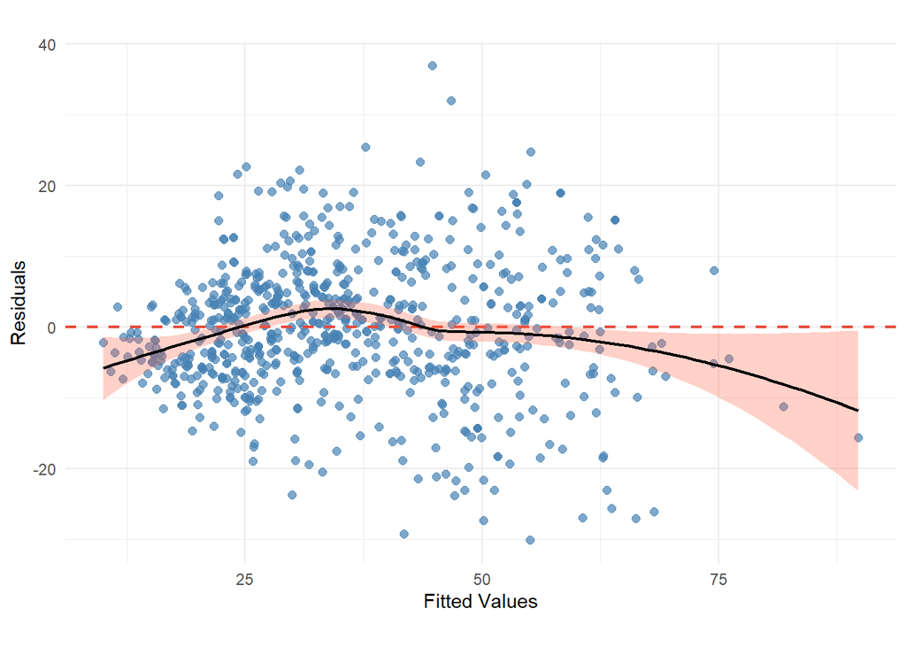

Additionally, a slight increase in the spread of residuals at higher fitted values suggests mild heteroscedasticity.

While the linear model provides a reasonable baseline, these findings indicate that exploring more flexible, non-linear algorithms could yield improved predictive performance and better account for the data’s structure.

### Generalized additive models

Generalized Additive Models (GAMs) provide a framework for extending standard linear models by allowing nonlinear functions of each variable while maintaining additivity.

We fitted a GAM using spline functions for the full set of variables and key interactions identified in the literature.

| term | edf | ref.df | statistic | p.value |
| --- | --- | --- | --- | --- |
| s(Cement) | 1.000 | 1.000 | 3.224 | 0.073 |
| s(Blast_Furnace_Slag) | 4.807 | 5.843 | 27.337 | 0.000 |
| s(Fly_Ash) | 7.499 | 8.338 | 2.748 | 0.004 |
| s(Water) | 8.301 | 8.650 | 5.167 | 0.000 |
| s(Superplasticizer) | 6.199 | 7.294 | 6.881 | 0.000 |
| s(Coarse_Aggregate) | 7.811 | 8.606 | 2.858 | 0.003 |
| s(Fine_Aggregate) | 8.653 | 8.946 | 13.234 | 0.000 |
| s(Age) | 7.967 | 8.417 | 3.596 | 0.000 |
| te(Water,Cement) | 14.310 | 15.989 | 3.267 | 0.000 |
| te(Water,Age) | 5.989 | 7.420 | 1.290 | 0.172 |
| te(Fly_Ash,Age) | 4.431 | 5.599 | 0.333 | 0.951 |

### Tree-based model

In this section, we fit another class of model: tree-based models, which can help account for the nonlinear and complex relationships between the features and the response.

While decision trees offer a number of advantages, they can be non-robust. Therefore, instead of fitting a single tree, we implemented a Random Forest, which fits multiple decorrelated trees on bootstrapped samples. We first fine-tuned the hyperparameters to maximize performance, then trained the final model on the full training set using the hyperparameters that optimized our cross-validation scores.

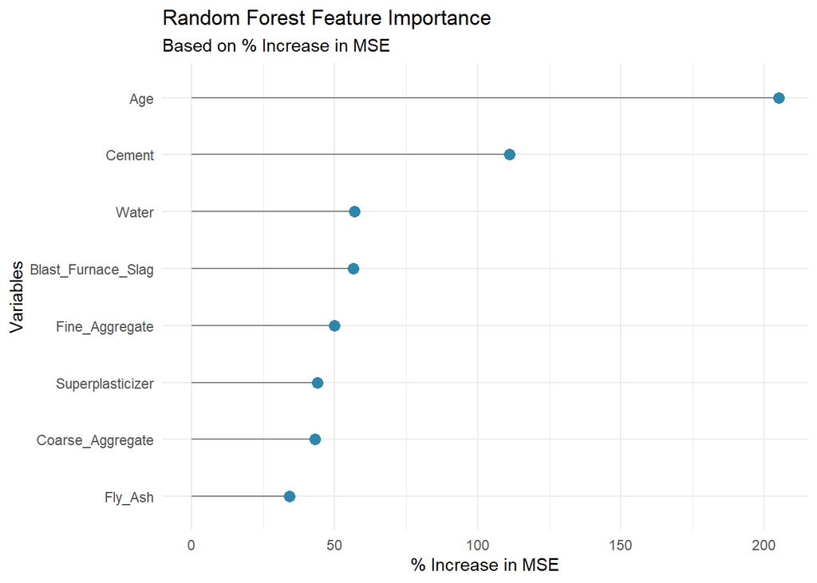

The random forest feature importance indicates that *age* and *cement* are the most dominant predictors of compressive strength. *Slag* and *water* also contribute meaningfully.

## Prediction Evaluation

To obtain a valid performance estimate, we assessed our three models using the untouched validation set in two steps:

- Plotting the predicted versus actual concrete compressive strength for each model.
- Calculating the following three metrics for each: Mean Squared Error (MSE), Root Mean Squared Error (RMSE), and R-squared.

### Graphical Model Assessment: Predicted vs. Actual Values

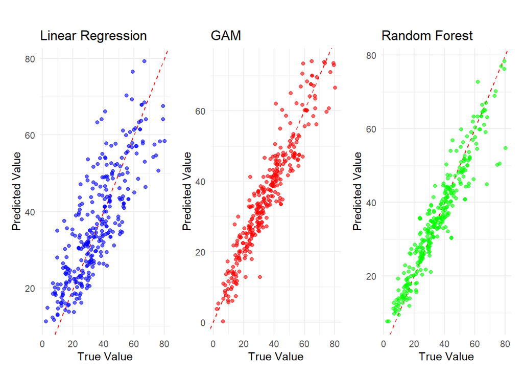

The predicted versus actual plot clearly differentiates model performance. The Linear Regression model shows points widely scattered around the diagonal line, indicating underfitting and a limited capacity to capture the underlying data structure. The GAM demonstrates significantly improved performance, with predictions more tightly aligned along the ideal fit line. The Random Forest model delivers the most accurate predictions, exhibiting the smallest dispersion of points around the diagonal, which confirms its superior ability to model the complex relationships in the data.

### Predictive Performance Assessment Using MSE, RMSE, and R²

| Model | MSE | RMSE | R² |
| --- | --- | --- | --- |
| Linear Regression | 90.948 | 9.537 | 0.668 |
| GAM | 30.177 | 5.493 | 0.890 |
| Random Forest | 27.901 | 5.282 | 0.898 |

As the results indicate, the Linear Regression model achieves an MSE of 90.948 and an R-squared of 0.668, representing a reasonable baseline. However, performance improves significantly with more flexible models. The MSE decreases by more than 60 points, and the R-squared shows a substantial improvement from 0.668 for the linear model to 0.890 for the Generalized Additive Model (GAM).

The Random Forest model, with fine-tuned hyperparameters, achieves even better predictive accuracy, reducing the MSE further from 30.18 (GAM) to 27.9. The R-squared values for the GAM and Random Forest, however, are nearly identical.

## Conclusion

In this project, the goal was to evaluate the performance of different models in predicting concrete compressive strength. We experimented with three approaches: Linear Regression, a Generalized Additive Model (GAM), and a Random Forest.

The results show that while Linear Regression provides a reasonable baseline, it fails to capture the true structure and nonlinearity in the data. The GAM achieves a good balance between predictive performance and interpretability, making it a strong middle-ground approach. Finally, the Random Forest, being more flexible and capable of modeling complex relationships, delivers the best overall predictive performance for this problem.